# R Notebook

# Exploring precipitation patterns

What is the best way to explore community responses to variation in precipitation patterns?

Papers on the subject seem to suggest a number of different ways to subset climate data to make sense of changes in community composition and productivity from year to year.

Some relevant citations and their approaches to using climate patterns:

- Dudney et al. (2016)

Included both current-year and previous-year rainfall effects divided into Fall (October - November), Winter (December - February), and Spring (March - May). Significant variables were current winter, current spring, previous fall, and previous spring. Coefficients of similar magnitudes suggest that no one season is most responsible for change.

- Adler and Levine (2007)

Included both current-year and previous-year rainfall effects, cumulatively by year. Also included transformations of variables to better account for nonlinearity of effects; current and last year richness / productivity was best explained by the inverse transformation of current and last year precipitation.

- Pitt and Heady (1978)

Included 76(!) variables in analysis – mean, minimum, and maximum temperatures, number of days receiving <6.35 mm rain, total precip, days below freezing, drough (longest successive number of days receiving <1.27 mm of rain), and germination date (number of days after 31 first storm of 19mm).

- Eviner (2015) has a general overview:

Plant production highest in years with high and steady rainfall between November and February, especially when temperatures are high in that period. Site-specific.

High precipitation with warm temperatures in the Fall tend to favor annual grasses, largely due to rapid germination in warm, moist conditions.

Fall rains followed by a prolonged fall or early-winter drought tend to favor forbs and legumes.

Prolonged mid-winter drouhgt tends to favor forbs, clovers, and perennial grasses.

Some potential variables of interest:

- 19mm (3/4") of an inch needed for grasses to germinate

Framework for how to measure climatic variables:

1. Define the start of each year’s germinating season (rainfall in 24hrs > 19mm)
2. Calculate a series of potential variables: * Date of season start and precip * Mean precip for each 30-day period following the season start * Total number of days without precipitation in 30-day intervals * Maximum number of sequential days without precipitation

# First date of sufficient germinating rains

Following figures show the first date when the total amount of precipitation exceeded 19mm in a rolling 7-day period.

| Water.Year | GermRain |
| --- | --- |
| 2006 | 2006-01-07 |
| 2007 | 2006-11-02 |
| 2008 | 2007-10-10 |
| 2009 | 2008-11-01 |
| 2010 | 2009-12-11 |
| 2011 | 2010-10-24 |
| 2012 | 2011-10-06 |
| 2013 | 2012-11-17 |
| 2014 | 2014-02-07 |
| 2015 | 2014-11-30 |

[output cut: 3 more lines]

# Average rain in each month

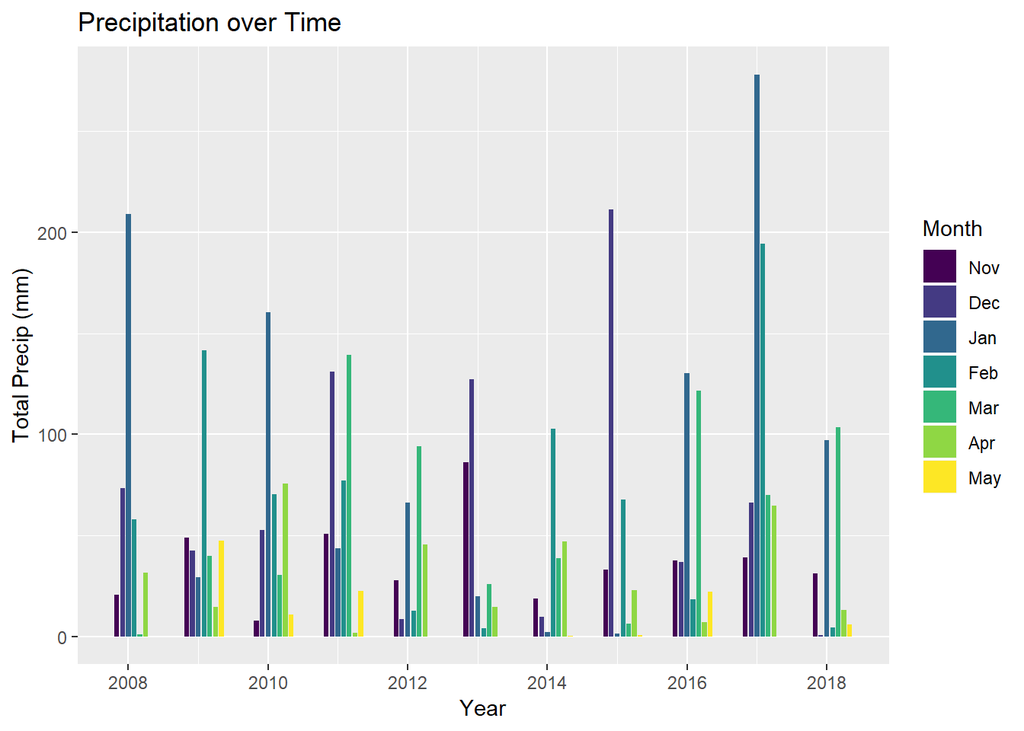

# CV of rainfall in each year

Another way to think about climatic stress would be to quantify how variable precipitation is in a given year – does consistent precipitation generate a different community than more variable precip? Here, the measure of a coefficient of variation ($CV = \dfrac{stddev}{mean}$) might be the best measure of variability.

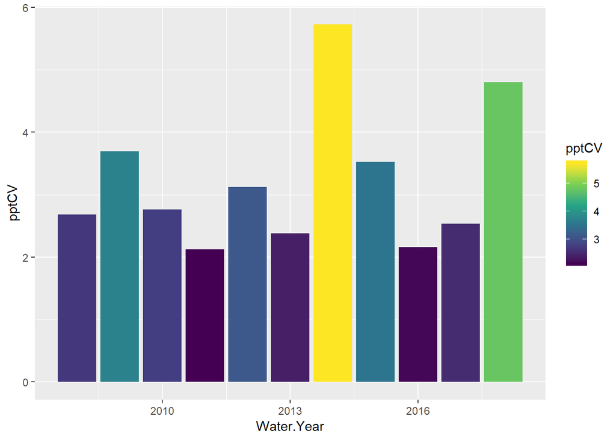

# Total number of days in each month with no rain (or less than 1mm?)

Following figures show the total number of days in each year where no rain is observed between November and March

| Water.Year | month | droughtdays |
| --- | --- | --- |
| 2006 | 1 | 25 |
| 2006 | 2 | 24 |
| 2006 | 3 | 15 |
| 2007 | 1 | 31 |
| 2007 | 2 | 18 |
| 2007 | 3 | 29 |
| 2007 | 11 | 24 |
| 2007 | 12 | 25 |
| 2008 | 1 | 19 |
| 2008 | 2 | 22 |

[output cut: 53 more lines]

| Water.Year | Total |
| --- | --- |
| 2006 | 64 |
| 2007 | 127 |
| 2008 | 122 |
| 2009 | 122 |
| 2010 | 112 |
| 2011 | 105 |
| 2012 | 130 |
| 2013 | 118 |
| 2014 | 131 |
| 2015 | 130 |

[output cut: 3 more lines]

# Length of droughts in each water year

We can also try to quantify the number and duration of droughts within each year - I’ve written a function that produces a table of all droughts (consecutive days with less than a mm of rain), and highlighted the maximum drought lenght in each year.

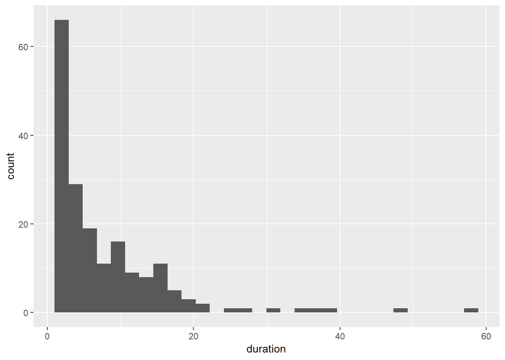

```
## Longest Observed Winter Droughts:
```

| Water.Year | dstart | dend | duration |
| --- | --- | --- | --- |
| 2006 | 2006-01-31 | 2006-02-17 | 17 days |
| 2007 | 2006-12-30 | 2007-02-07 | 39 days |
| 2008 | 2007-11-12 | 2007-12-04 | 22 days |
| 2009 | 2008-11-04 | 2008-11-26 | 22 days |
| 2010 | 2009-11-01 | 2009-11-17 | 16 days |
| 2010 | 2010-03-13 | 2010-03-29 | 16 days |
| 2011 | 2011-01-14 | 2011-01-29 | 15 days |
| 2011 | 2011-01-31 | 2011-02-15 | 15 days |
| 2012 | 2011-12-16 | 2012-01-20 | 35 days |
| 2013 | 2013-01-24 | 2013-02-19 | 26 days |

[output cut: 5 more lines]